# Macro Defense Rotation

**Warning**

**Price History**

Normalised price history of the 4 defensive ETFs + SPY benchmark since 2007, rebased to 100.

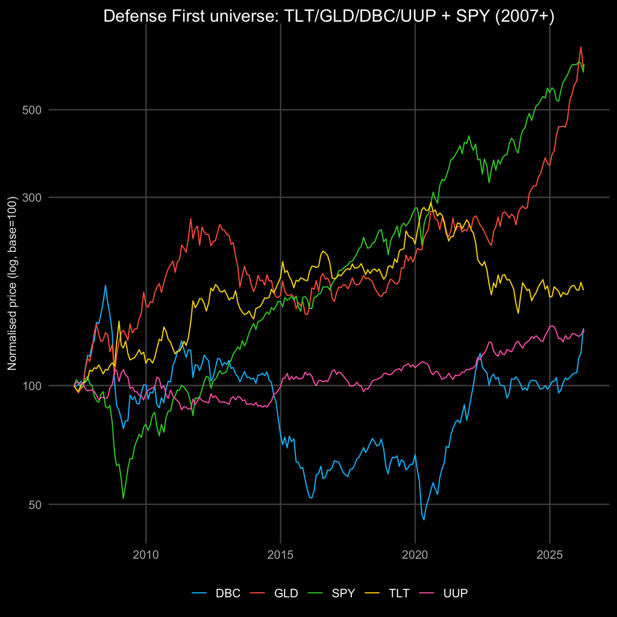

**TLT (Treasuries), GLD (Gold), DBC (Commodities), UUP (USD Index), SPY (S&P 500).** Y: normalised price (log scale, rebased to 100). Each covers a different macro risk regime. Source: `hd_ohlcv()` via `hd_group("Defense First")`.

**Correlation**

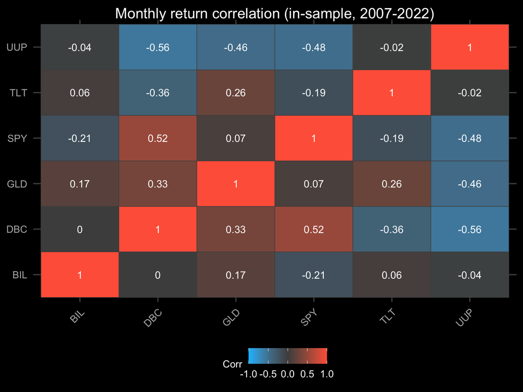

**Metadata**

| ticker | long_name | currency | exchange | market_cap | volume_avg | yield_pct | beta_3yr | start_date | end_date | total_obs |
| --- | --- | --- | --- | --- | --- | --- | --- | --- | --- | --- |
| DBC | Invesco DB Commodity Index Tracking Fund | USD | PCX | 3174899968 | 1393577 | 0.0257 | 0.191 |  |  |  |
| GLD | SPDR Gold Shares | USD | PCX | 113784938496 | 18825185 | 0 | 0.153 |  |  |  |
| SPY | State Street SPDR S&amp;P 500 ETF Trust | USD | PCX | 623596208128 | 88635881 | 0.0114 | 1 | 1993-01-29 | 2026-04-10 | 8356 |
| TLT | iShares 20+ Year Treasury Bond ETF | USD | NGM | 9487952896 | 40516631 | 0.044899996 | 0.111 |  |  |  |
| UUP | Invesco DB US Dollar Index Bullish Fund | USD | PCX | 576161856 | 2445967 | 0.033299997 | -0.036 |  |  |  |

**Regime Map**

Which hedge ranked #1 each month based on the expanding-window composite momentum signal.

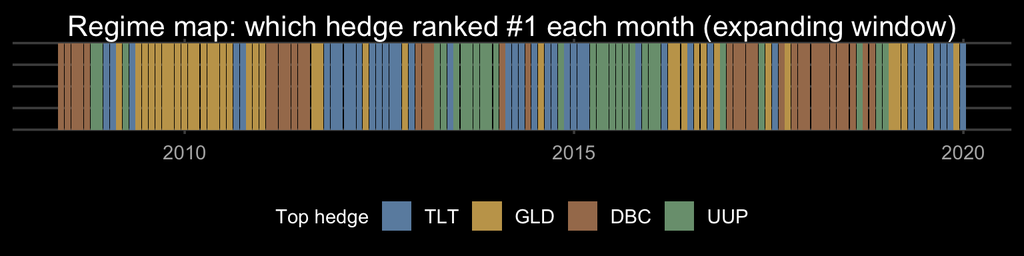

**Monthly regime map.** Colour = top-ranked hedge by composite momentum (avg of 1/3/6/12-month returns). TLT (steel blue) = deflation/easing. GLD (muted gold) = monetary instability. DBC (brown) = inflation/commodities. UUP (sage) = USD strength. Expanding window: each month uses all prior data, no lookahead.

**Equity Curve**

**EXPLORATORY / IN-SAMPLE.** Defense First rotation vs SPY buy-and-hold.

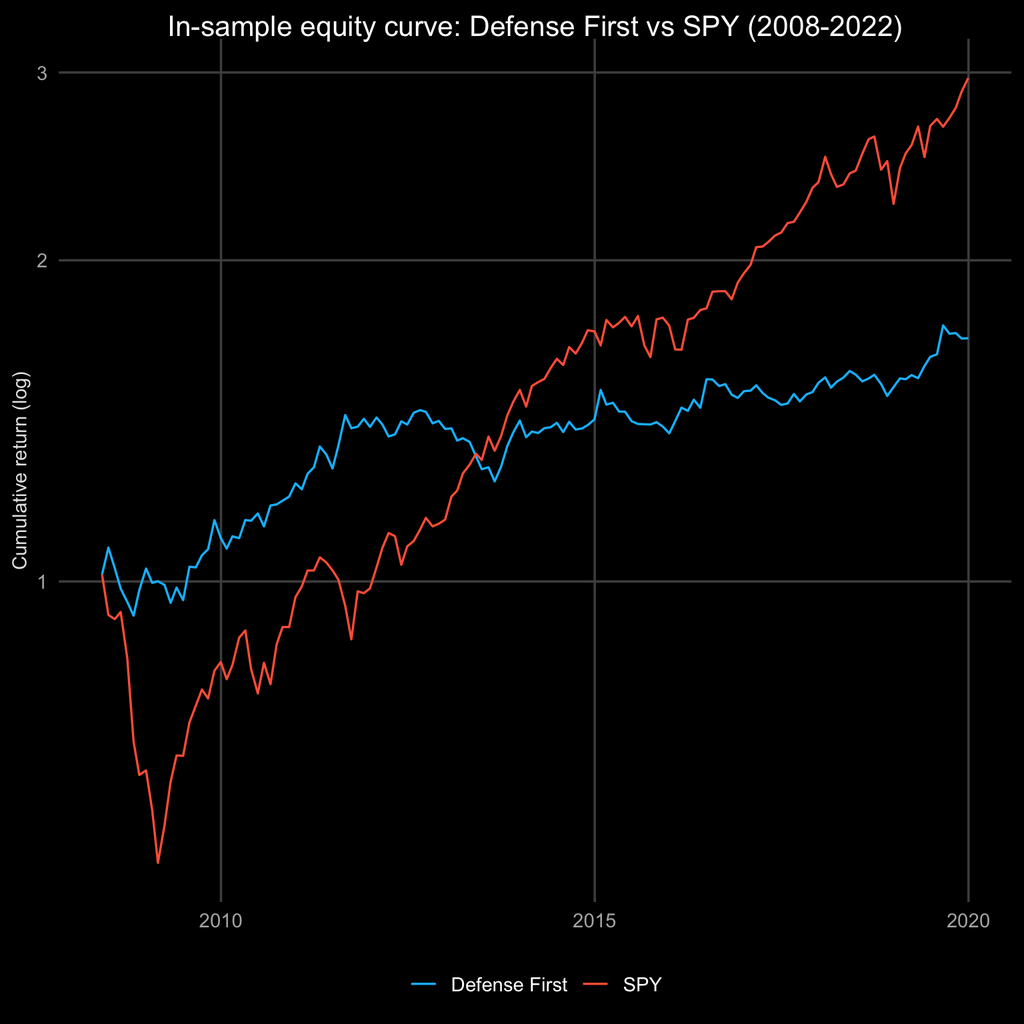

**In-sample equity curves (log scale).** Defense First (blue) vs SPY (red). The strategy sacrifices upside for dramatically lower drawdowns. SPY CAGR higher but max DD -46% vs Defense First -14%. EXPLORATORY — in-sample only.

**Drawdowns**

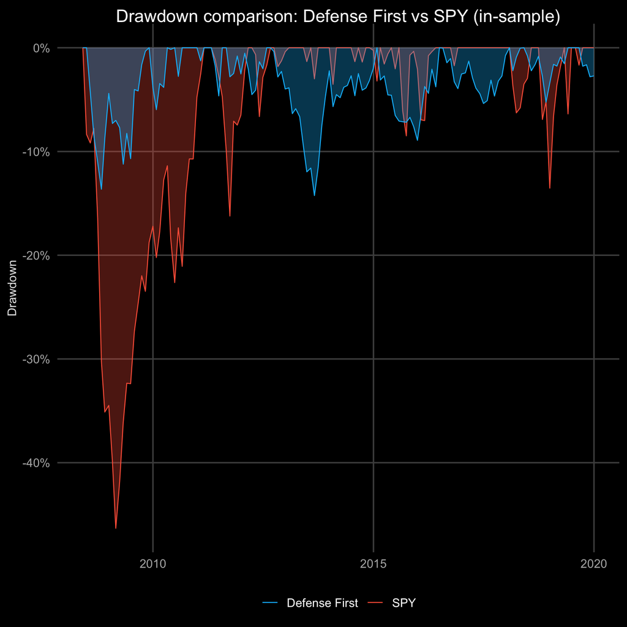

**Metrics**

| strategy | n_months | years | cagr | vol | sharpe | sortino | max_dd | calmar | hit_rate |
| --- | --- | --- | --- | --- | --- | --- | --- | --- | --- |
| Defense First | 140 | 11.7 | 4.6% | 8.8% | 0.47 | 1.1 | -14.2% | 0.32 | 55% |
| SPY (buy &amp; hold) | 140 | 11.7 | 9.8% | 14.9% | 0.62 | 0.82 | -46.3% | 0.21 | 68.6% |

**Scatter**

Does the composite momentum signal predict next month’s return?

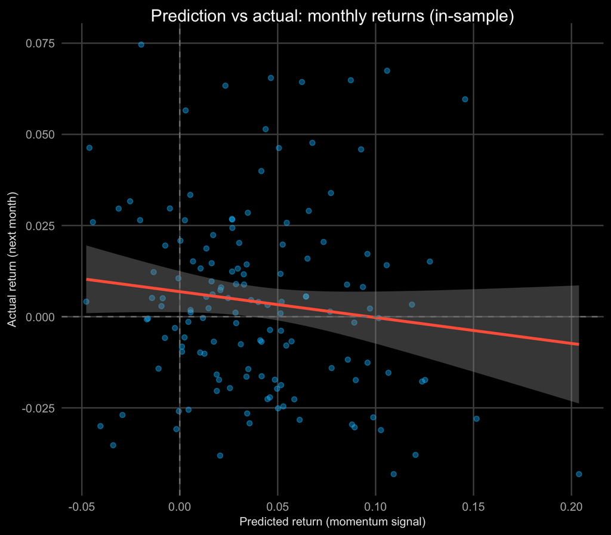

**Predicted vs actual monthly returns.** X: composite momentum signal (weighted trailing returns). Y: realised portfolio return next month. Positive slope = signal has predictive power. Wide scatter = noisy prediction (expected for monthly returns). In-sample.

**Hit Rate Over Time**

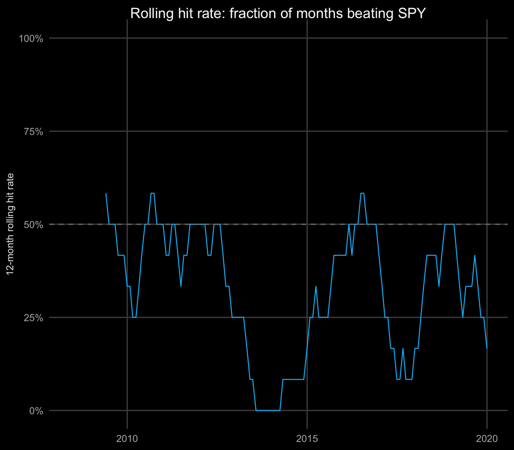

**12-month rolling hit rate** (fraction of months portfolio beats SPY). Above 50% dashed line = strategy outperforming on a rolling basis. The strategy is designed for defense (reducing losses) not for beating SPY in all regimes. In-sample.

**Comparison Table**

| strategy | n_months | years | cagr | vol | sharpe | max_dd | calmar |
| --- | --- | --- | --- | --- | --- | --- | --- |
| Defense First (momentum) | 140 | 11.7 | 4.6% | 8.8% | 0.47 | -14.2% | 0.32 |
| SPY (buy &amp; hold) | 140 | 11.7 | 9.8% | 14.9% | 0.62 | -46.3% | 0.21 |
| Equal weight (25% each) | 152 | 12.7 | 3.5% | 7.3% | 0.38 | -21.9% | 0.16 |
| Top 1 only (100%) | 140 | 11.7 | 3.5% | 15.9% | 0.18 | -28.9% | 0.12 |

**Equity Curves**

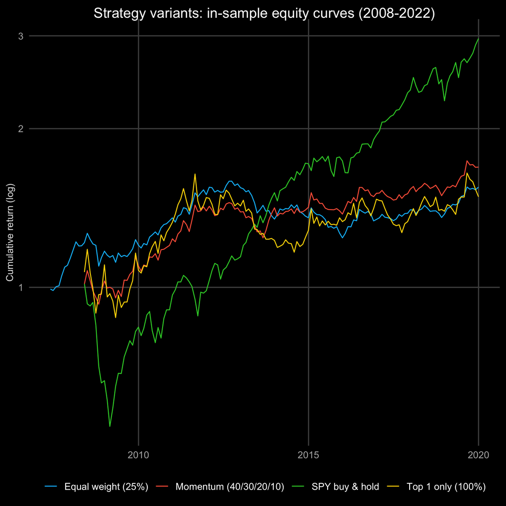

**4 strategy variants compared.** Momentum rotation (40/30/20/10), equal weight (25% each), top-1 concentrated (100%), and SPY benchmark. All in-sample. Momentum rotation balances return and risk.

**Weight History**

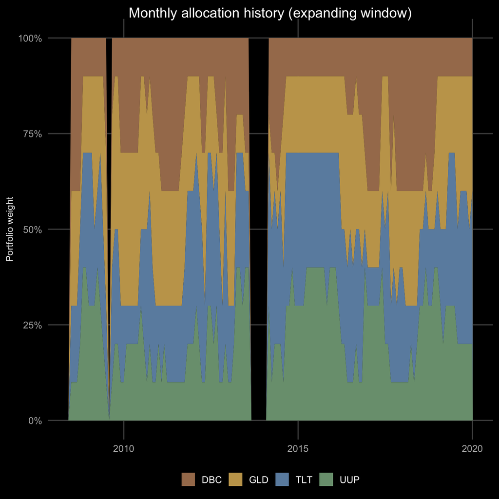

**Individual Weights**

Unstacked view — each ETF’s weight shown separately.

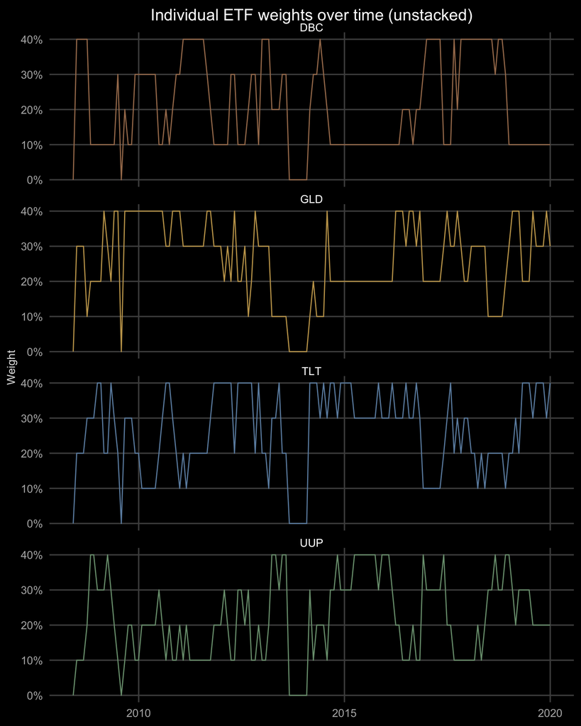

**IS vs OOS Metrics**

[output not shown]

**OOS Equity Curve**

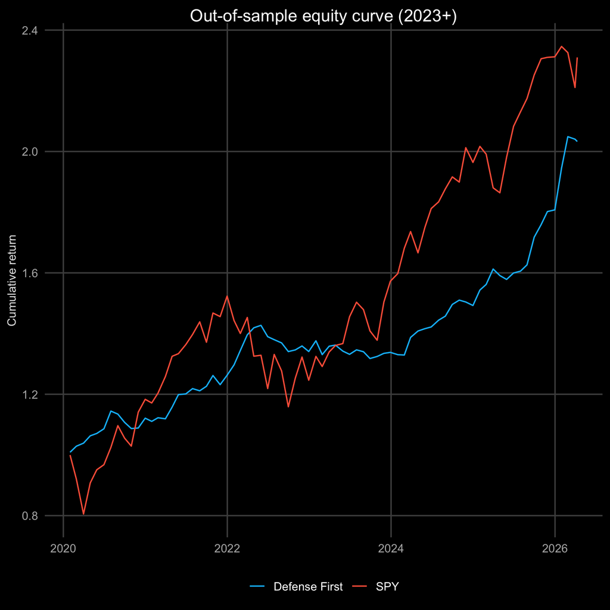

**Full-Period Scatter (IS + OOS)**

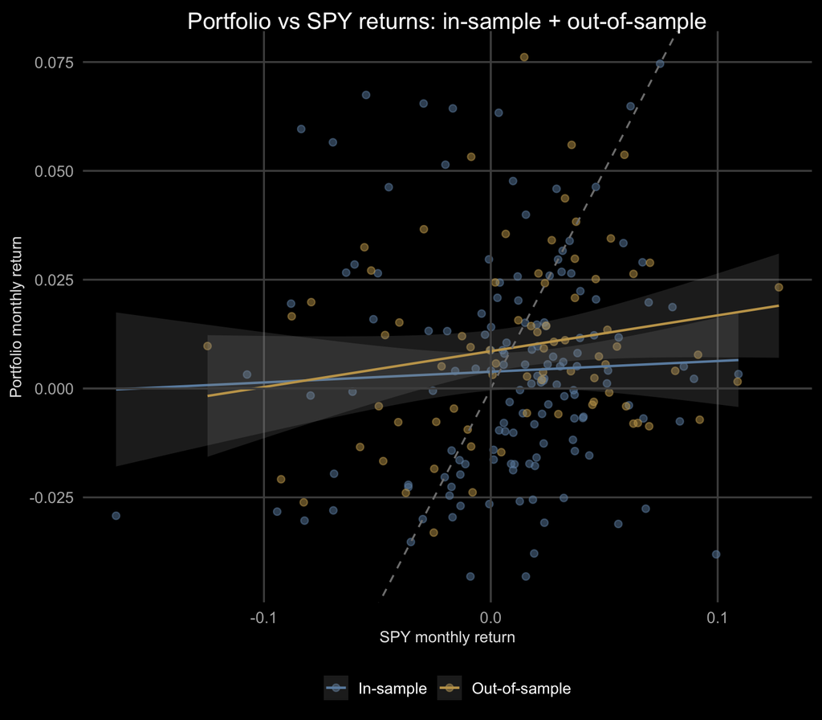

**Full-Period Hit Rate**

Rolling 12-month fraction of months beating SPY, including OOS.

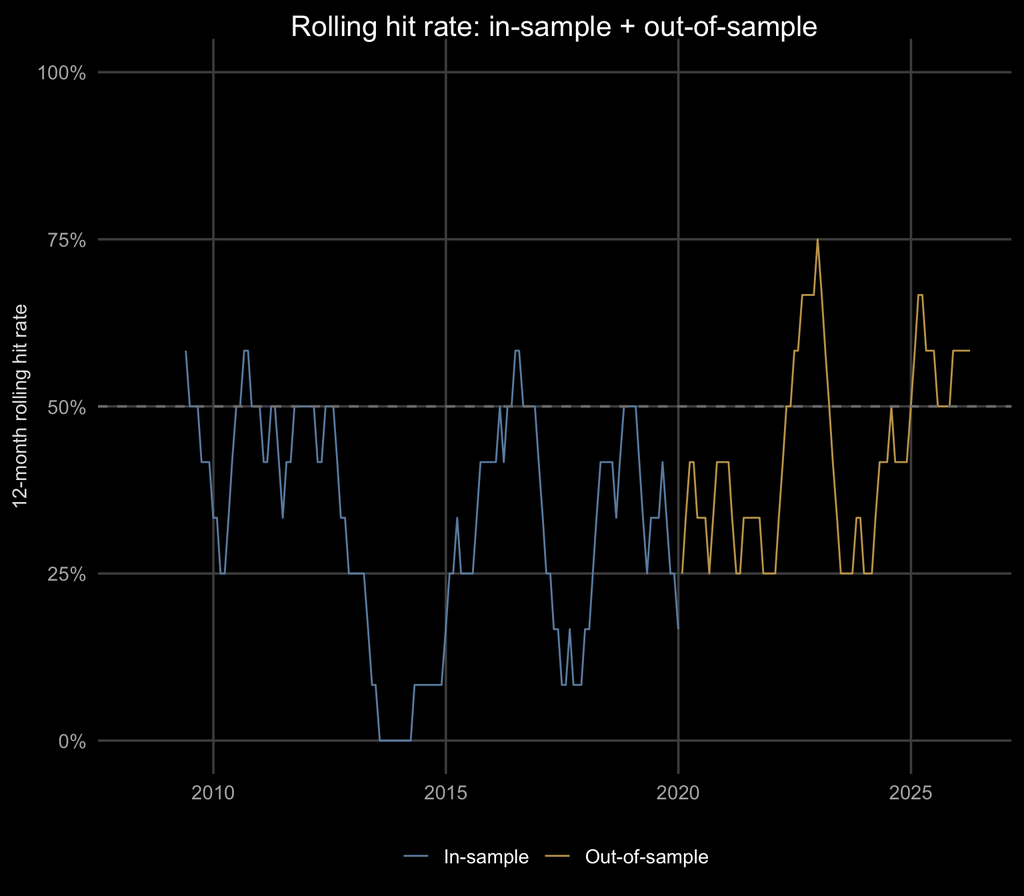

**Full-period rolling hit rate.** Steel blue = in-sample. Gold = out-of-sample. The strategy beats SPY roughly 35-40% of months — it’s a defense strategy, not an alpha strategy. Value comes from limiting drawdowns, not from monthly outperformance.

**Article vs Our Results**

To replicate the article’s exact numbers: (1) fixed lookback windows (not expanding), (2) start Jan 2009 (not 2008), (3) full period including 2023-2026 (no OOS holdout).

| source | months | years | cagr | vol | sharpe | max_dd | calmar |
| --- | --- | --- | --- | --- | --- | --- | --- |
| Article claims | 207 | 17.2 | 10.8% | NA% | 1.01 | -10% | 1.33 |
| Our replication (fixed lookback, 2009+) | 196 | 16.3 | 7.4% | 7.6% | 0.81 | -14.2% | 0.52 |
| SPY (our data, 2009+) | 196 | 16.3 | 13.7% | 14.3% | 0.88 | -23.9% | 0.57 |
| Article SPY | 207 | 17.2 | 14% | NA% |  | NA% | 0.58 |

**Replication comparison.** “Article claims” = numbers from the source. “Our replication” = same methodology (fixed lookback) on our data. Differences may arise from: data source (yfinance vs article’s source), exact month-end dates, dividend/split adjustments.

**Replication Equity Curve**

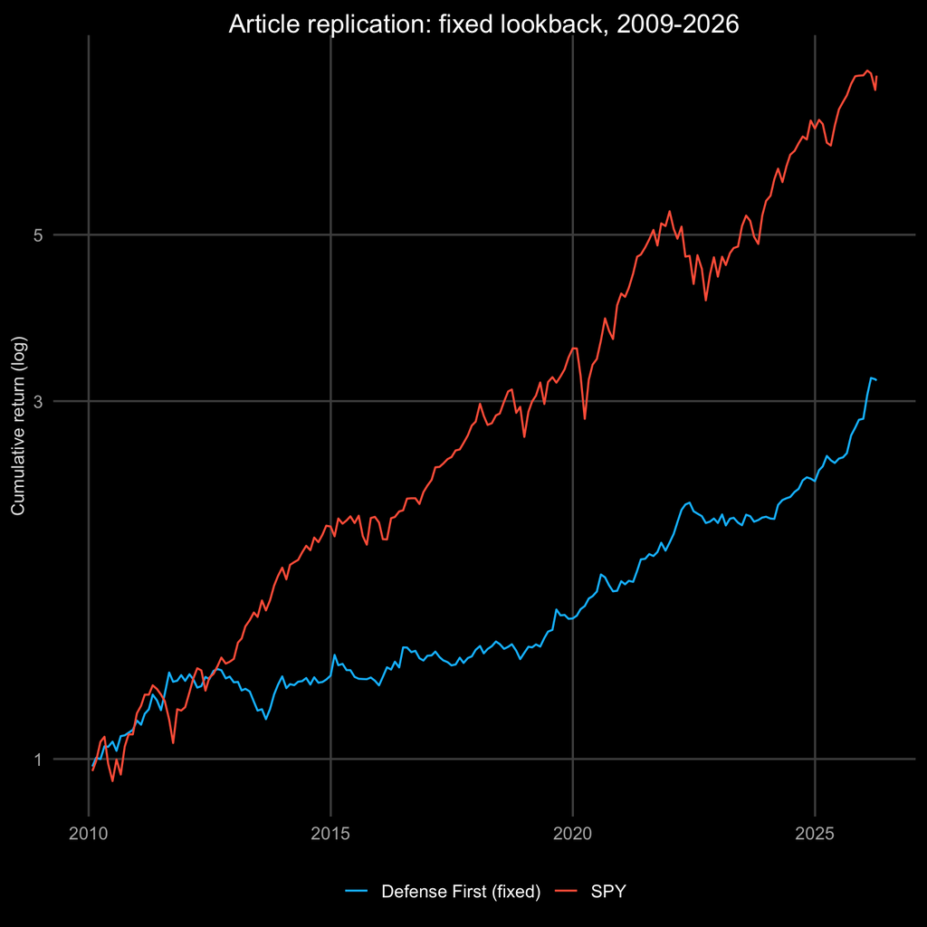

**Expanding vs Fixed**

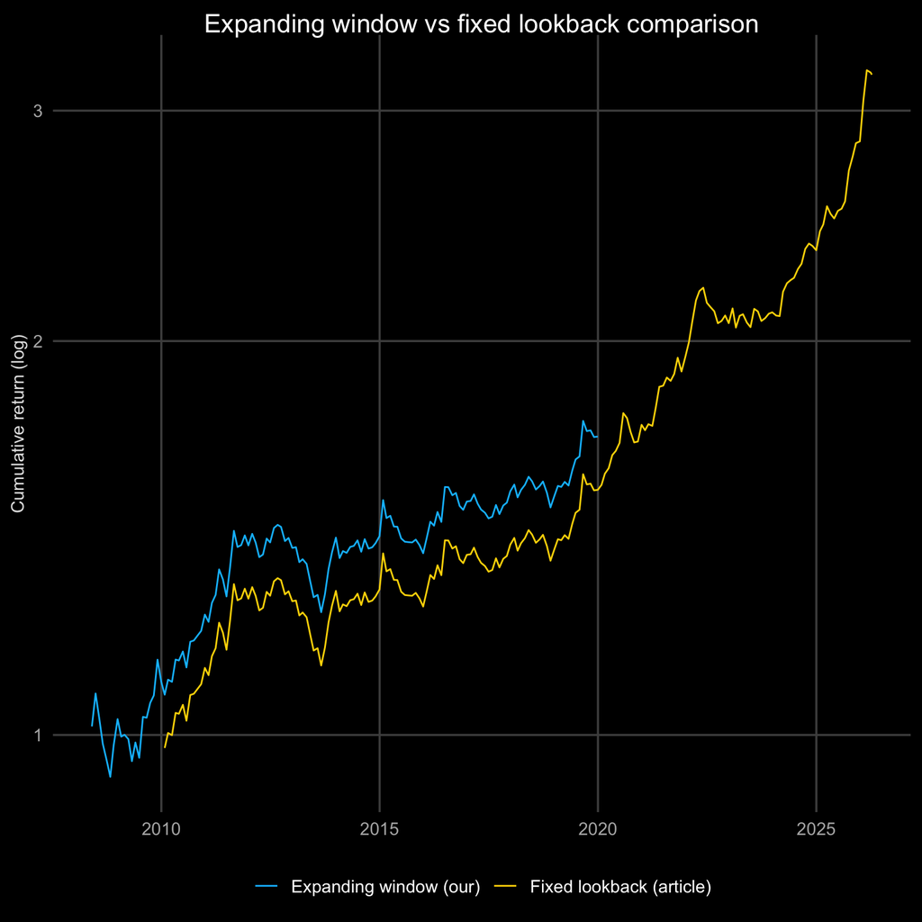

**Methodological comparison.** Expanding window (blue, our approach) vs fixed lookback (gold, article’s approach). Fixed lookback is more responsive but more prone to whipsaws. Expanding window is more conservative but reduces overfitting risk.

**Strategy Summary**

**Defense First** is a macro rotation strategy that rotates among 4 defensive ETFs, each covering a different risk regime:

| ETF | Asset Class | Hedges Against | Regime |
| --- | --- | --- | --- |
| TLT | Long-duration US Treasuries | Deflation, Fed easing | Rates falling |
| GLD | Gold | Monetary instability, falling real rates | Currency debasement |
| DBC | Broad commodities | Stagflation, supply shocks | Inflation rising |
| UUP | US Dollar index | Global stress, funding crises | Flight to USD |

**Benchmark:** SPY (S&P 500 ETF). The strategy aims to protect against drawdowns, not necessarily beat SPY in bull markets.

**Source:** [Defense First: When Not Losing is Winning](https://notfinancial.substack.com/p/defense-first-when-not-losing-is)

**Implementation**

**Signal:** Composite momentum — equal-weighted average of 1, 3, 6, and 12-month simple returns for each ETF.

**Allocation by rank:**

| Rank | Weight |
| --- | --- |
| 1st (strongest momentum) | 40% |
| 2nd | 30% |
| 3rd | 20% |
| 4th (weakest) | 10% |

**Fallback:** If all 4 hedge ETFs score below BIL (1-3 month T-bills = cash proxy), allocate 100% to SPY instead.

**Rebalance:** Monthly at month-end close.

**Our modification:** We use an **expanding window** (all available history) instead of the article’s fixed lookback. This is more conservative — the signal adapts more slowly but reduces overfitting risk. See the Replication tab for the fixed-lookback comparison.

**Transaction costs:** Not modelled. Article estimates ~0.60% annual drag at 25bps per trade, reducing CAGR from 10.83% to 10.17%.

**Notes**

**Expanding window vs fixed lookback:**

- **Fixed lookback** (article): each month, compute 1/3/6/12-month returns using only those trailing months. More responsive to regime changes. Risk: whipsaws in volatile periods.
- **Expanding window** (our approach): each month, compute momentum using ALL data from start to current month. More conservative. Risk: slower to adapt to new regimes.

**In-sample vs out-of-sample:**

**Caveats:**

- This is educational, not investment advice
- No transaction costs modelled
- Survivorship bias: we only test ETFs that exist today
- Data source differences may cause replication gaps
- Monthly rebalancing assumes month-end execution at close price

**Glossary**

| Term | Definition |
| --- | --- |
| CAGR | Compound Annual Growth Rate — annualised return |
| Sharpe Ratio | (Return - Risk-free rate) / Volatility. Higher = better risk-adjusted return |
| Calmar Ratio | CAGR / Max Drawdown. Higher = better drawdown-adjusted return |
| Sortino Ratio | Like Sharpe but uses downside deviation only |
| Max Drawdown | Largest peak-to-trough decline |
| Hit Rate | Fraction of months portfolio beats benchmark |
| Expanding Window | Uses all data from start to current date (grows each month) |
| Fixed Lookback | Uses only the last N months (window size stays constant) |
| OOS | Out-of-sample — data not used during strategy development |
| Momentum | Tendency for assets that performed well recently to continue |

**References**

1. **Source article:** [Defense First: When Not Losing is Winning](https://notfinancial.substack.com/p/defense-first-when-not-losing-is) — Not Financial Advice (Substack)
2. **Data source:** [historicaldata](https://huggingface.co/datasets/JohnGavin/finance-data) R package via DuckDB `hf://` protocol
3. **TLT:** [iShares 20+ Year Treasury Bond ETF](https://www.ishares.com/us/products/239454/)
4. **GLD:** [SPDR Gold Shares](https://www.spdrgoldshares.com/)
5. **DBC:** [Invesco DB Commodity Index Tracking Fund](https://www.invesco.com/us/financial-products/etfs/product-detail?audienceType=Investor&productId=ETF-DBC)
6. **UUP:** [Invesco DB US Dollar Index Bullish Fund](https://www.invesco.com/us/financial-products/etfs/product-detail?audienceType=Investor&productId=ETF-UUP)
7. **Backtesting methodology:** Expanding window to avoid lookahead bias. See [Advances in Financial Machine Learning](https://www.wiley.com/en-us/Advances+in+Financial+Machine+Learning-p-9781119482086) (de Prado, 2018) for methodology.

**Related Vignettes**

- **Avoid Worst Days** — theoretical analysis of return asymmetry; Macro Defense Rotation is the practical, tradeable counterpart
- **European Overlay** — applies a similar regime-detection logic using ECB CISS systemic-stress data across European equities
- **Strategy Leaderboard** — comparative ranking of Macro Defense Rotation against all other strategies

**Build Info**

**Data**

*Hover any item for its exact provenance. This is a static snapshot — it does not refresh itself.*

| Item | Value |
| --- | --- |
| Commit | [`84da1e5`](https://github.com/JohnGavin/historical/commit/84da1e5ebd7ce3a4d7a55d836e0d0a02a680d338) |
| Branch | `main` |
| Source tree | dirty (1 source file modified: .claude/CURRENT_WORK.md) |
| Data sources referenced | HuggingFace (parquet via hf://), FRED (Federal Reserve Economic Data), Ken French Data Library, ECB (European Central Bank, CISS), JST Macrohistory Database, CBOE (VIX/VVIX), Yahoo Finance, Alpha Vant… |
| Targets in store | 1545 |
| Store last built | 2026-10-27 21:02 GMT |
| Open issues | [Open issues](https://github.com/JohnGavin/historical/issues) |

**R environment**

| Item | Value |
| --- | --- |
| R | `4.5.3` |
| historicaldata package Imports | `cli 3.6.5`, `DBI 1.3.0`, `digest 0.6.39`, `dplyr 1.2.1`, `duckdb 1.5.1`, `duckplyr 1.2.1`, `ggplot2 4.0.2`, `lubridate 1.9.5`, `MASS 7.3.65`, `purrr 1.2.1`, `rlang 1.1.7`, `slider 0.3.3`, `stats 4.5.… |

**This page**

| Item | Value |
| --- | --- |
| Theme | dark = `darkly`, light = `cosmo` (Bootswatch) |
| Fonts | no custom `font-family` override in vignette-shared.css — inherits the Bootswatch theme’s default stack |
| Chart engine | ggplot2 (static PNG/SVG via knitr) |
| Table engine | DT `0.34.0` |